# Data Camp / Forecasting Using R - Chapter 2

Initialize and load the data

```r
library(ggplot2)
library(forecast)
library(fpp)
```

Chapter 2 of [Data Camp - Forecasting Using R](https://www.datacamp.com/courses/forecasting-using-r)

## Forecast intervals

The **forecast** is the mean of multiple possible futures based on the history. This is often called the “point forecast”.

The default R forecasting functions produce the **forecast** + shaded areas representing the 80% and 95% regions. The model is interpreted such that the expectation is that 1/2 of future points will fall above the **forecast** line and 1/2 below and 80% within the 80% region and 20% outside of it, etc.

The most simple model is the **naiive** model, which is implemented in R with the `naive()` function and simply uses the last known point as the forecast moving forward.

To include a *seasonal* component the `snaive()` function provides the ability to use the point from some previous period, i.e. use last March’s value to predict this Marches value.

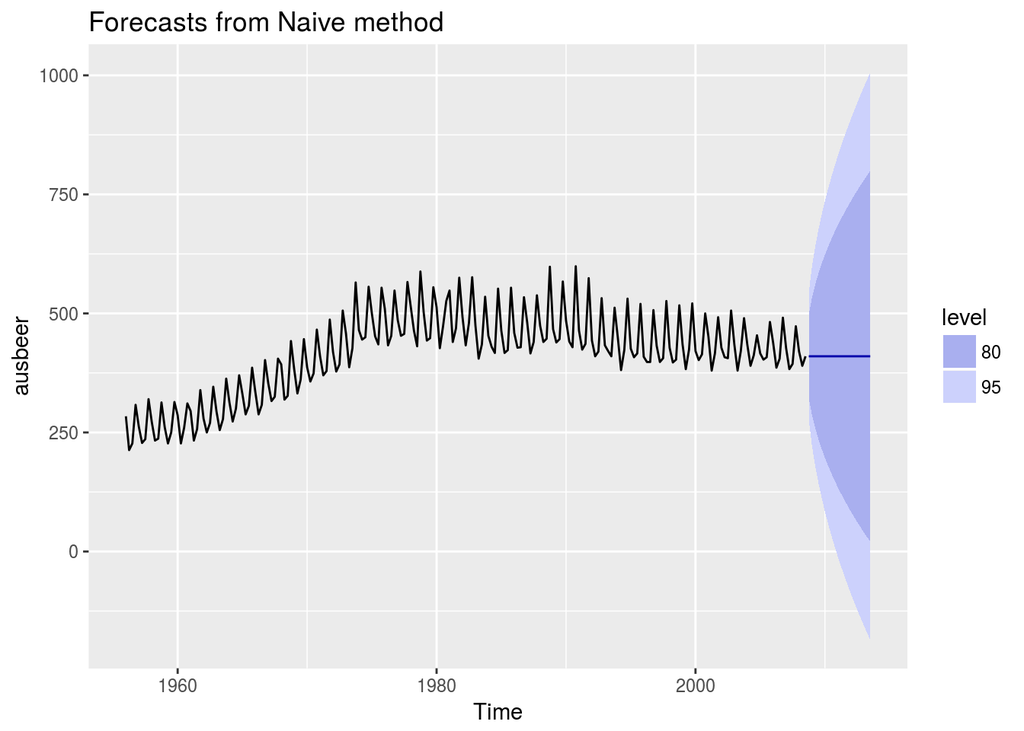

```r
fcbeer = naive(ausbeer, h=20)
autoplot(fcbeer)
```

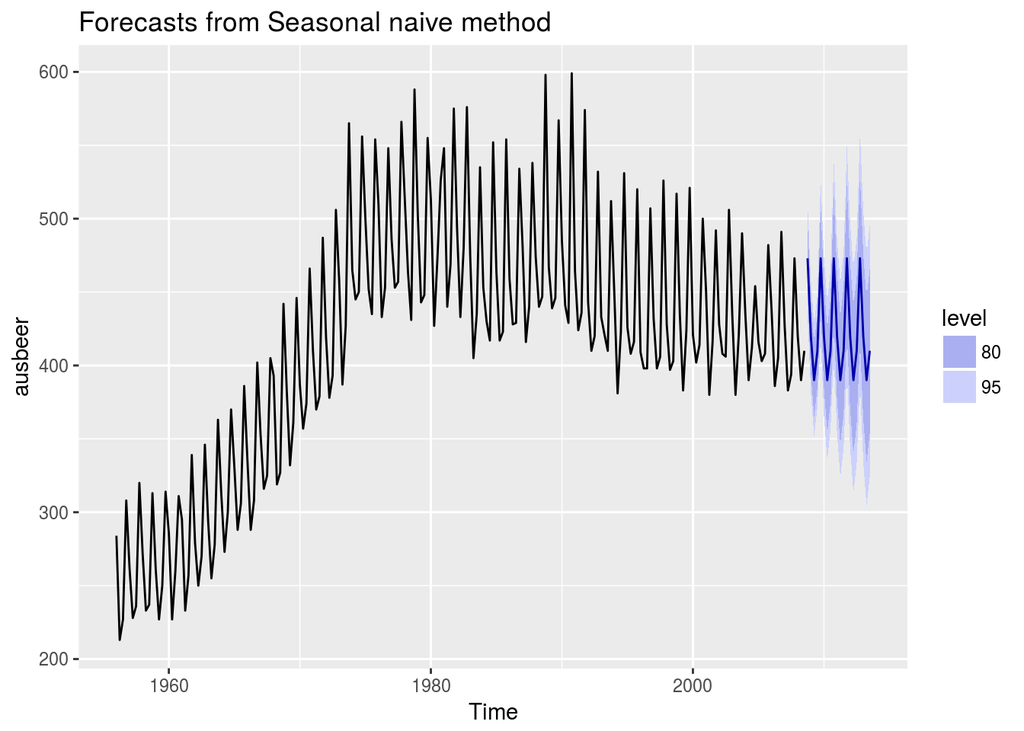

```r
fcbeers = snaive(ausbeer, h=20)
autoplot(fcbeers)
```

## Fitted values and residuals

A *fitted value* is the forecast of an observation using all previous observations.

A *residual* is the difference between the forecasted value and the actual observation.

## Residuals should look like white noise

### Essential assumptions about *residuals*

- They should be uncorrelated. If there is some correlation then the model can be refined.
- They should have 0 mean. Otherwise the forecast has **bias**, the forecast can be adjusted until there is 0 mean.

Not essential but important

- They should have constant variance
- They should be normally distributed

When forecasting you should split data into a **training** and **test** set to avoid **overfitting** a model.

The difference between the actual values from the **test** set and the model results are called **forecast errors** vs. **residuals**.

## Measures of forecast accuracy

Definitions: $y_t$ = Observation  
$\hat{y_t}$ = Forecast  
$e_t = y_t - \hat{y_t}$ = Forecast error

There are several measures of accuracy

| Accuracy measure | Calculation |
| --- | --- |
| Mean Absolute Error | $MAE = E(\bracevert e_t \bracevert)$ |
| Mean Squared Error | $MSE = E(e_t^2)$ |
| Mean Absolute Percentatage Error | $MAPE = 100 \times E(\bracevert\frac{e_t}{y_t}\bracevert)$ |
| Mean Absolute Scaled Error | $ MASE = MAE / Q$ (Where $Q$ is a scaling constant) |

$E()$ is the **E**xpected value or *Average* and is defiend as $E(x) = \frac{1}{N} \sum_{n=1}^N{x_n}$

In all cases a *small* value is better.

In R the `accuracy()` fn will do most of the heavy lifting in testing accuracy of a model.

```r
train <- window(gold, end = 1000)
m1 = naive(train)
m2 = snaive(train)
m3 = meanf(train)

accuracy(m1, gold)
```

```
##                      ME     RMSE      MAE        MPE     MAPE     MASE
## Training set 0.09161392 6.339770 3.158386 0.01662141 0.794523 1.000000
## Test set     9.47000000 9.904898 9.470000 2.24751984 2.247520 2.998367
##                    ACF1 Theil's U
## Training set -0.3098928        NA
## Test set     -0.2752626  2.558586
```

```r
accuracy(m2, gold)
```

[output not shown]

```r
accuracy(m3, gold)
```

```
##                         ME     RMSE      MAE       MPE      MAPE      MASE
## Training set -4.239671e-15 59.17809 53.63397 -2.390227 14.230224 16.981449
## Test set      2.920198e+01 29.34590 29.20198  6.940585  6.940585  9.245854
##                    ACF1 Theil's U
## Training set  0.9907254        NA
## Test set     -0.2752626  7.382684
```

## Time series cross-validation

This method sets up several training and test sets. In a 1 step model, a subset of the data is used as the training and the next point the test, everything else is not used. Then the training set is increased by 1 point as well as the test set and repeat until you reach the end of the data.

You can then estimate the error by averaging the error over all the *tiny* test sets.

The R function `tsCV()` will do this for you.

- Choose the model with smallest MSE.